# Exercise 5

### Overview

Let us first take a look at the data. Let us see what variable it has, what kind of variable they are. Also we will check if there is any correlations between the variables.

```r
human <- read.csv('human.csv',row.names = 1)
str(human)
```

```
## 'data.frame':    155 obs. of  8 variables:
##  $ eduFM    : num  1.007 0.997 0.983 0.989 0.969 ...
##  $ labFM    : num  0.891 0.819 0.825 0.884 0.829 ...
##  $ ExpEdu   : num  17.5 20.2 15.8 18.7 17.9 16.5 18.6 16.5 15.9 19.2 ...
##  $ ExpLife  : num  81.6 82.4 83 80.2 81.6 80.9 80.9 79.1 82 81.8 ...
##  $ GNI      : int  64992 42261 56431 44025 45435 43919 39568 52947 42155 32689 ...
##  $ MMR      : int  4 6 6 5 6 7 9 28 11 8 ...
##  $ BirthRate: num  7.8 12.1 1.9 5.1 6.2 3.8 8.2 31 14.5 25.3 ...
##  $ PP       : num  39.6 30.5 28.5 38 36.9 36.9 19.9 19.4 28.2 31.4 ...
```

The variables stand for:

- eduFM = (Proportion of females with at least secondary education) / (Proportion of males with at least secondary education)
- labFM = (Proportion of females in the labour force)/(Proportion of males in the labour force)
- ExpEdu = Expected years of schooling
- ExpLife = Life expectancy at birth
- GNI = Gross National Income per capita
- MMR = Maternal mortality ratio
- BirthRate = Adolescent birth rate
- PP = Percetange of female representatives in parliament

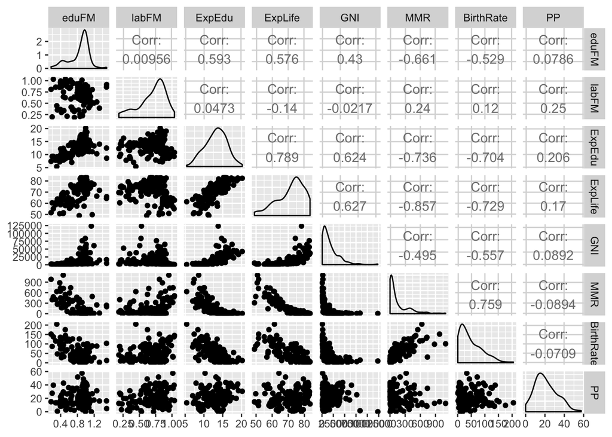

```r
library(dplyr)
library(ggplot2)
library(GGally)

ggpairs(human)
```

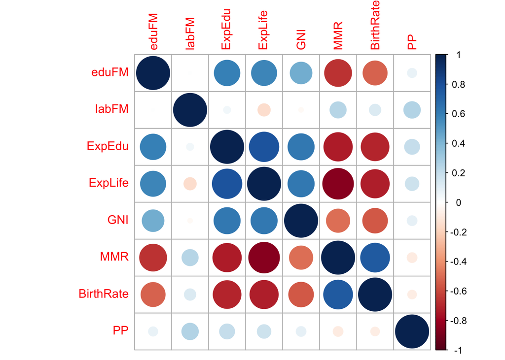

```r
cor(human) %>%corrplot::corrplot()
```

We notice that there is a highly negative correlation between MMR and ExpLife. That means that the bigger chance to die during the birth the shorter life is. Also, ExpEdu (Expected years of schooling) and ExpLife (Life expectancy at birth) have a strong positive correlation.

### PCA on the non standardized data

Now it is time to perform PCA. I am going to do it on the non standardized data.

```r
pca_non_sta <- prcomp(human)
summary(pca_non_sta)
```

```
## Importance of components:
##                              PC1      PC2   PC3   PC4   PC5   PC6    PC7
## Standard deviation     1.854e+04 185.5219 25.19 11.45 3.766 1.566 0.1912
## Proportion of Variance 9.999e-01   0.0001  0.00  0.00 0.000 0.000 0.0000
## Cumulative Proportion  9.999e-01   1.0000  1.00  1.00 1.000 1.000 1.0000
##                           PC8
## Standard deviation     0.1591
## Proportion of Variance 0.0000
## Cumulative Proportion  1.0000
```

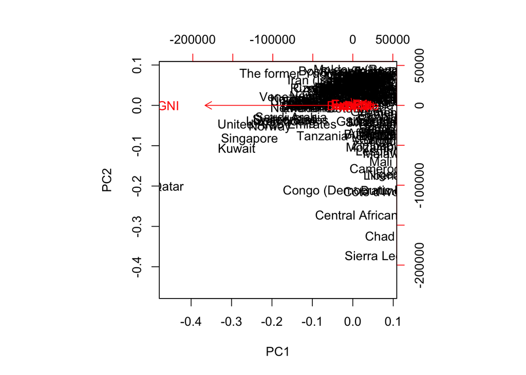

```r
biplot(pca_non_sta, choices = 1:2)
```

The results we got don’t make sense at all. The reason for it is that our data is not standardized.

### PCA on the standardized data

Let us do PCA on the standardized data this time.

```r
human <- scale(human) # standardizing
pca_sta <- prcomp(human)
summary(pca_sta)
```

```
## Importance of components:
##                           PC1    PC2     PC3     PC4     PC5     PC6
## Standard deviation     2.0708 1.1397 0.87505 0.77886 0.66196 0.53631
## Proportion of Variance 0.5361 0.1624 0.09571 0.07583 0.05477 0.03595
## Cumulative Proportion  0.5361 0.6984 0.79413 0.86996 0.92473 0.96069
##                            PC7     PC8
## Standard deviation     0.45900 0.32224
## Proportion of Variance 0.02634 0.01298
## Cumulative Proportion  0.98702 1.00000
```

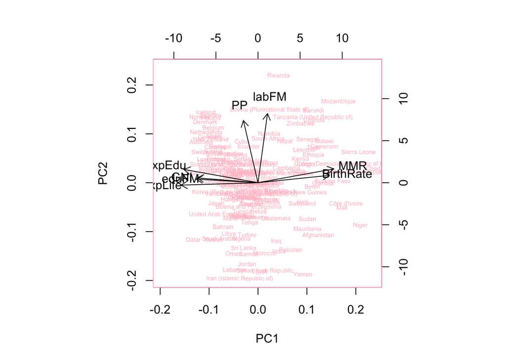

```r
biplot(pca_sta, choices = 1:2, cex = c(0.5, 1), col = c("pink", "black"))
```

The analysis on the standardized data produces more realstic and more useful results than the previous one did.

### Interpretation

The high maternal mortality ratio and the high adolescent birth rate are one of the signs of the developing country. On the other hand, hign education, long life and hinf GNI are something that is often related to the developed countries. So the first principal component measures how much the country is developed.

The second component have a strong positive correlation with PP and labFM, when PP stands for percetange of female representatives in parliament and labFM - female proportion in the labour force compared to male one. I would say that this component show how equal women are compared to the men.

### Tea data

Now we are going to do MCA on the tea dataset.

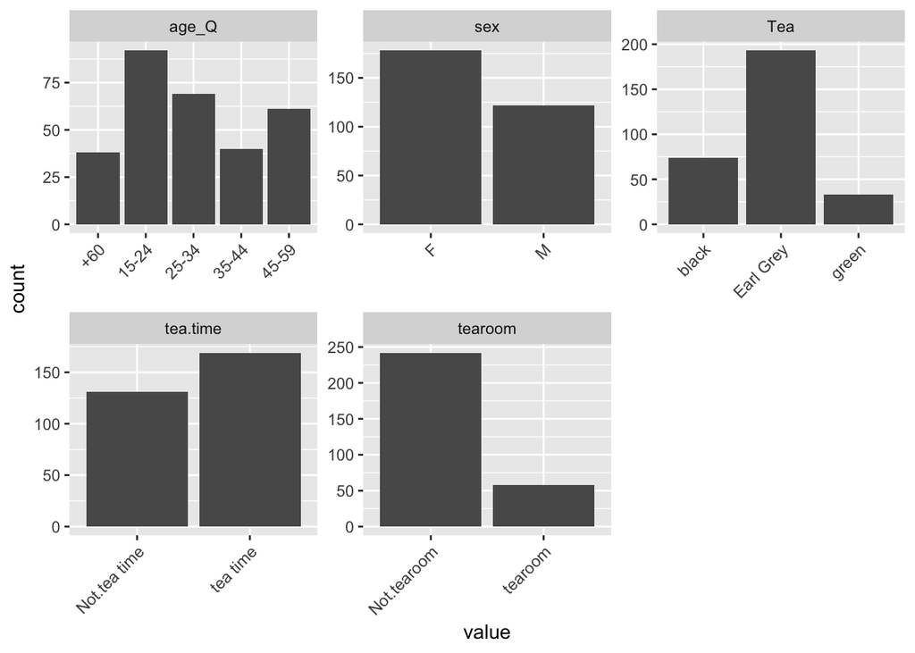

```r
# download "tea"
library(FactoMineR)
library(tidyr)
data(tea)
tea <- dplyr::select(tea, one_of(c("tea.time", "tearoom", "Tea","age_Q", "sex")))
tea <- filter(tea, complete.cases(tea))
gather(tea) %>% ggplot(aes(value)) +
  facet_wrap("key", scales = "free") +
  geom_bar() +
  theme(axis.text.x = element_text(angle = 45, hjust = 1, size= 9))
```

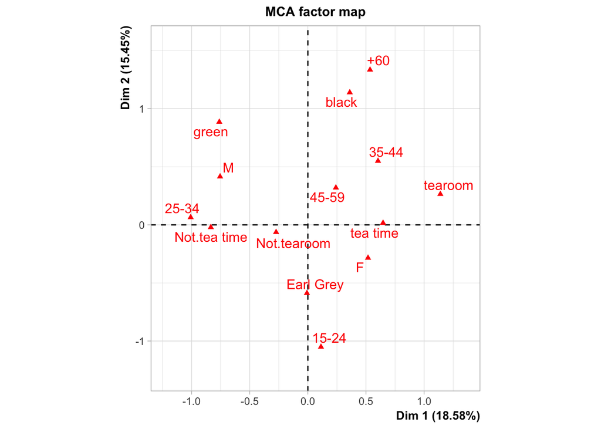

```r
mca <- MCA(tea, graph = FALSE)
plot(mca, invisible = c("ind"))
```

What I notice is that women are more likely to have tea time and tearooms that men. Also black tea is the most popular among old people 60+. Young people between 25-34 don’t usually have any tea time.